# POMP Modeling for Spot-futures Spreads by a Variation of CIR Model

Stats 531 Final Project

# Introduction

In this project, we use a variation of Ornstein-Uhlenbeck processes$^{[1]}$ which is a Markovian process and the IF2 algorithm$^{[2]}$ to find an appropriate model for spot-futures spread$^{[3]}$. The POMP$^{[4]}$ simulations are beneficial for exploration of the proper form of the model and the FLUX is conducive to the estimation of parameters. We model the spot-futures spread time series by POMP which was covered in class to give some statistical, mathematical and financial explanations for empirical phenomena. At the beginning I was going to continue the exploration of second order dependence of log returns, but after doing research, in order to avoid overlapping, I chose the spreads as the topic. The spreads have nice statstical properties because theoretically it should have expectation close to 0 given the maturity is small$^{[5]}$. The spreads also have signicant economic meaning because they can be constructed from two actively traded assets. Modelling the dynamics of the spreads is of great meaning.

## Raising Questions

The cointegration of S&P500Index and S&P500Futures Index&$^{[6]}$ in my midterm project aroused my curiosity of finding the patterns of the spreads. Are they approximately Markovian? Will the spreads behave like individual stock or interest rate? Do they have heavier tails than normal distribution does? Should the coefficients of drift terms and diffusion terms be constants or deterministic functions or even progressively measurable random variables? A series of questions about the spreads interest me a lot. Being haunted by these questions, I turned to papers first to see how predecessors deal with these problems.

## Literature Reviews

Spreads are the difference between price of spot and futures. Financial stock indexes are observed to be fitted quite well by fractional Ornstein-Uhlenbeck process$^{[7]}$. However, the fractional Ornstein-Uhlenbeck process is not markovian$^{[8]}$. Although the estimates can be obtained in other methods$^{[9]}$, let us focus on spreads models that can be modeled by Partially Observed Markovian process about which we have learned the theory and saw many cases in lecture notes$^{[10]}$. Depending on market conditions, the spreads can be either positive or negative, and so different from interest rates, the choice of an Ornstein-Uhlenbeck process makes sense$^{[11]}$. Wavelet analysis was also applied to analyze the dynamics between spot and futures$^{[12]}$. The distribution of spreads are poorly modeled by normal distribution and have heavier tails and asymmetry$^{[13]}$.Daily spreads and nonstorable commodities spreads are less normally distributed than weekly and storable commodities spreads are are. Hence, as traders search for the probability distributions of spreads, each spread is likely to have its own unique characteristics, making it difficult for trade$^{[14]}$. In order to take care of the autocorrelation, assymetry and tails, we use a variation of Cox–Ingersoll–Ross model which is Markovian and has nice mathematical characteristics and interpretable parameters.

# Introduction of Data

The CSI 300 Index and futures data I analyzed is the close price and last settlement price of CSI300 Index and futures from Jan 2st 2014 to Feb 23th, 2018 because the spreads in a less mature and efficient market volatiles more and revert to 0 more slowly$^{[15]}$. The data is downloaded from Factset at Tozzi Financial Trading Center, Ross School of Business, University of Michigan. The HangSeng Index and futures, S&P500 Index and futures are from the same source and all end on Feb 23th, 2018.

```r
CSI300Index=read.csv(file = "https://raw.githubusercontent.com/RickYuankangHung/Quant-python/master/CSI300IndexPriceHistory.csv",header = T)
CSI300FuturesIndex=read.csv(file="https://raw.githubusercontent.com/RickYuankangHung/Quant-python/master/CSI300ContinuousPriceHistory.csv",header = T)
CSIspreads_value=(array(rev(as.numeric(as.character(CSI300Index$Price))))[2151:3194])-(array(rev(as.numeric(as.character(CSI300FuturesIndex$SettlementPrice)))))
# dow$Adj_Close=rev(CSI300Index$Price)
# CSIspreads_value
```

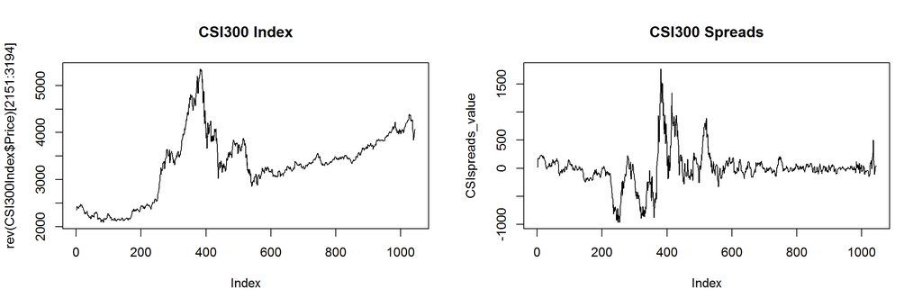

```r
par(mfrow=c(1,2))
plot(rev(CSI300Index$Price)[2151:3194],type='l',main="CSI300 Index")
plot(CSIspreads_value,type = 'l',main="CSI300 Spreads")
```

Observing the plot of spreads, we may first find that the mean is almost 0. The volatility varies as time goes by. The tail is quite heavy. The mean reversion speed is proportional to its deviation from mean. The volatility is small when the magnitude of spread is small. The volatility becomes greater when the magnitude of spread is big. Importantly, the volatility is always dominated by the mean reversion. As what we can see, although during some periods of time the volatility is extremely big, it always come back to mean within a not long period of time. From economic perspective, the greater volatility of spreads clusters when the trend of the Index changes especially in the bearish market when there is sharp sell-off of futures by institutional investors. However, no matter how volatile the spread is, as long as there is no default in settlement, the spread will come back to the mean because arbitrage push thee price of spot and futures to converge. Obtaining these features, we build the model for spreads.

# Dynamics of Spread

The following model is built to capture what we observed in the previous graph. This is the model selected from several models. Other models have flaws such as explosion, lack of volatility, improper kurtosis, non-mean reversion. This model solves these flaws and is qutie interpretable.

## Continuous Model for Spread

$$dY_t=a (b-Y_{t-1})dt+(\sigma+ s\sqrt{|Y_{t-1}|})dW_t$$
$dW_t$ is Wiener processe.

1.Parameter a captures the speed of mean reversion. It can take value between 0 and 1.

2.Parameter b depicts the mean of the spreads. Because the spreads can be any real value as long as the prices are possible, b can take any real value. Theoretically, it should be close to 0.

3.The drift coefficient is a linear form of $Y_{t-1}$ because the mean reversion speed is proportional to its deviation from mean.

4.The diffusion term is to describe the volatility of spread. Because the diffusion should be dominated by the mean reversion effect, otherwise it may diverge and never come back to the mean(this happens in some simulations of other models), the $Y_{t-1}$ has the power of $\frac{1}{2}$. To make it meaningful when $Y_{t-1}$ take negative value, we take the absolute value of $Y_{t-1}$.

5.Parameter serves as scale of the volatility to make the model simulations volatile as much as the data do.

6.Parameter $\sigma$ was introduced as the floor of volatility because we observed that even when the spreads are zero, it still volatiles in a range.

## Discrete Model for Spread

We write the discrete form for this model:
$$Y_n-Y_{n-1}=a (b-Y_{n-1})+(\sigma+ s\sqrt{|Y_{n-1}|})\epsilon_n\\
\text{Model Representation:}\\Y_n=X_n+V_n\epsilon_n\\X_n=a (b-Y_{n-1})+Y_{n-1}\\V_n=(\sigma+s\sqrt{|Y_{n-1}|})$$
where ${\epsilon_n}$ is an iid $N(0,1)$ sequence. $Y$ denotes the spread. $X$ denotes the latent process. $V$ denotes the volatility latent process.

- Parameters have constrained conditions:

# Building a POMP model

Based on the previous model, we build a POMP model.

```r
require(pomp)

CSIspreads_statenames <- c("X","V","Y_state")
CSIspreads_rp_names <- c("sigma","a","b","s")
CSIspreads_ivp_names <- c("X_0","V_0")
CSIspreads_paramnames <- c(CSIspreads_rp_names,CSIspreads_ivp_names)
CSIspreads_covarnames <- "covaryt"

rproc1 <- "
  X=a*(b-Y_state)+Y_state;
  V = sigma+s*sqrt(abs(Y_state));
"
rproc2.sim <- "
  Y_state = rnorm( X,V );
 "
rproc2.filt <- "
  Y_state = covaryt;
 "
CSIspreads_rproc.sim <- paste(rproc1,rproc2.sim)
CSIspreads_rproc.filt <- paste(rproc1,rproc2.filt)
```

```r
CSIspreads_initializer <- "
  V = V_0;
  X = X_0;
  Y_state = rnorm( X,V );
"
CSIspreads_rmeasure <- "
   y=Y_state;
"
CSIspreads_dmeasure <- "
   lik=dnorm(y,X,V,give_log);
"
```

It is better to convert parameters to the whole real value range, so we use log&exp to transform parameters constrained larger than 0, and use logit&expit to transform parameters within (0,1).

```r
CSIspreads_toEstimationScale <- "
  Tsigma = log(sigma);
  Ts = log(s);
  Ta=logit(a);
"
CSIspreads_fromEstimationScale <- "
  Tsigma = exp(sigma);
  Ts = exp(s);
  Ta=expit(a);
"
```

To justify and test our model, we choose a set of parameters and simulate data from the model and then we compare the original data and simulated data.

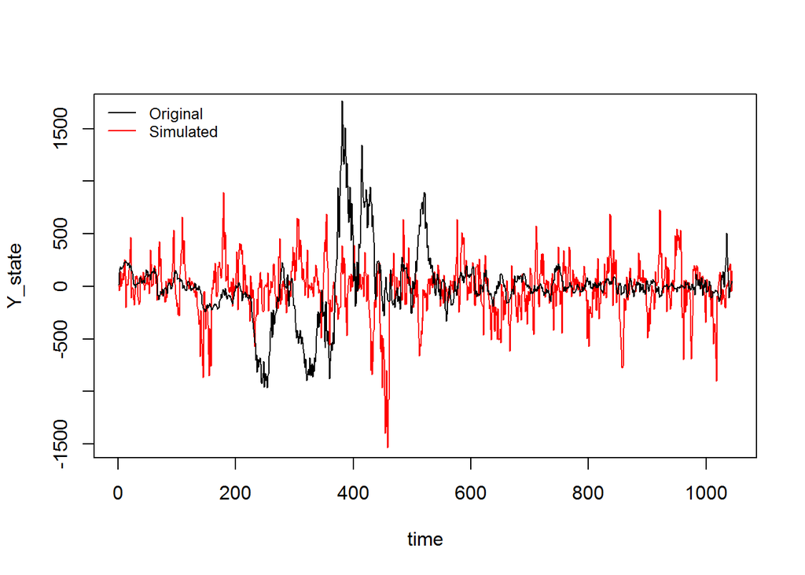

```r
##----------test for parameters--------------##
dow.filt <- pomp(data=data.frame(y=CSIspreads_value,
                     time=1:length(CSIspreads_value)),
              statenames=CSIspreads_statenames,
              paramnames=CSIspreads_paramnames,
              covarnames=CSIspreads_covarnames,
              times="time",
              t0=0,
              covar=data.frame(covaryt=c(0,CSIspreads_value),
                     time=0:length(CSIspreads_value)),
              tcovar="time",
              rmeasure=Csnippet(CSIspreads_rmeasure),
              dmeasure=Csnippet(CSIspreads_dmeasure),
              rprocess=discrete.time.sim(step.fun=Csnippet(CSIspreads_rproc.filt),delta.t=1),
              initializer=Csnippet(CSIspreads_initializer),
              toEstimationScale=Csnippet(CSIspreads_toEstimationScale),
              fromEstimationScale=Csnippet(CSIspreads_fromEstimationScale)
)

expit<-function(real){1/(1+exp(-real))}
logit<-function(p.arg){log(p.arg/(1-p.arg))}

params_test <- c(
     sigma =30,
     a=0.15,
     b = 0,
     s=10,
     V_0= 1.1,
     X_0=1
  )
set.seed(700)
sim1.sim <- pomp(dow.filt,
               statenames=CSIspreads_statenames,
               paramnames=CSIspreads_paramnames,
               covarnames=CSIspreads_covarnames,
               rprocess=discrete.time.sim(step.fun=Csnippet(CSIspreads_rproc.sim),delta.t=1)
)

sim1.sim <- simulate(sim1.sim,seed=1,params=params_test)
plot(Y_state~time,data=sim1.sim,type='l',col="red",ylim=c(-1500,1700))
lines(CSIspreads_value,type='l')
legend("topleft",legend=c("Original","Simulated"),col=c("black","red"),
       cex=0.8,lty=1,bty="n")
```

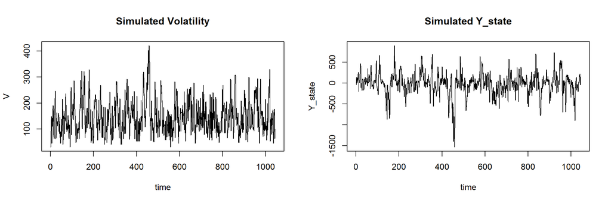

```r
par(mfrow=c(1,2))
plot(V~time,data=sim1.sim,type='l',main="Simulated Volatility")
plot(Y_state~time,data=sim1.sim,type='l',main="Simulated Y_state")
```

From the plot, we can see that our model is reasonable. We have also tried other models and parameter values. Only some appropriate values such as the test values make the patterns similar to what we see in the historical data.

# Filtering on simulated data

Then we check that whether we can filter on simulated data and try to gain more knowledge on the range of parameters. We set three different run levels. We get an log-likelihood estimate of -7.494654e+03 with a Monte standard error of 2.083143e-04.

```r
##--------filtering on simulated data----------
run_level <- 3
CSIspreads_Np <-          c(100,1e3,5e3)
CSIspreads_Nmif <-        c(10, 100,300)
CSIspreads_Nreps_eval <-  c(4,  10,  30)
CSIspreads_Nreps_local <- c(10, 20, 30)
CSIspreads_Nreps_global <-c(10, 20, 50)
```

```r
require(doParallel)
registerDoParallel(2)
```

```r
sim1.filt <- pomp(sim1.sim,
  covar=data.frame(
    covaryt=c(obs(sim1.sim),NA),
    time=c(timezero(sim1.sim),time(sim1.sim))),
  tcovar="time",
  statenames=CSIspreads_statenames,
  paramnames=CSIspreads_paramnames,
  covarnames=CSIspreads_covarnames,
  rprocess=discrete.time.sim(step.fun=Csnippet(CSIspreads_rproc.filt),delta.t=1)
)

stew(file=sprintf("pf1.rda",run_level),{
  t.pf1 <- system.time(
    pf1 <- foreach(i=1:CSIspreads_Nreps_eval[run_level],.packages='pomp',
                   .options.multicore=list(set.seed=TRUE),.export = c('run_level', 'CSIspreads_Np', 'CSIspreads_Nmif', 'CSIspreads_Nreps_eval', 'CSIspreads_Nreps_local','CSIspreads_Nreps_global','sim1.filt')) %dopar% try(
                     pfilter(sim1.filt,Np=CSIspreads_Np[run_level])
                   )
  )
},seed=493536993,kind="L'Ecuyer")
(L.pf1 <- logmeanexp(sapply(pf1,logLik),se=TRUE))
```

```
##                          se
## -7.494654e+03  2.083143e-04
```

# Fitting the model to the spreads

We now start to filter on the spreads. We set run level as 3.

```r
##---------Fitting the stochastic leverage model to Dow-Jones data------------
run_level <- 3
CSIspreads_Np <-          c(100,1e3,5e3)
CSIspreads_Nmif <-        c(10, 100,300)
CSIspreads_Nreps_eval <-  c(4,  10,  30)
CSIspreads_Nreps_local <- c(10, 20, 30)
CSIspreads_Nreps_global <-c(10, 20, 50)

CSIspreads_rw.sd_rp <- 0.001
CSIspreads_rw.sd_ivp <- 0.001
CSIspreads_cooling.fraction.50 <- 0.5

params_test <- c(
     sigma =70,
     a=0.15,
     b = 0,
     s=15,
     V_0= 2.1,
     X_0=4
  )

stew(file=sprintf("mif1-%d.rda",run_level),{
   t.if1 <- system.time({
   if1 <- foreach(i=1:CSIspreads_Nreps_global[run_level],
                  .packages='pomp', .combine=c,
                  .options.multicore=list(set.seed=TRUE),.export = c('CSIspreads_Np',
'CSIspreads_Nmif','CSIspreads_Nreps_eval','CSIspreads_Nreps_local','CSIspreads_Nreps_global','CSIspreads_rw.sd_rp','CSIspreads_rw.sd_ivp','CSIspreads_cooling.fraction.50','dow.filt','run_level','params_test')) %dopar% try(
                    mif2(dow.filt,
                         start=params_test,
                         Np=CSIspreads_Np[run_level],
                         Nmif=CSIspreads_Nmif[run_level],
                         cooling.type="geometric",
                         cooling.fraction.50=CSIspreads_cooling.fraction.50,
                         transform=TRUE,
                         rw.sd = rw.sd(
                           sigma=CSIspreads_rw.sd_rp,
                          a=CSIspreads_rw.sd_rp,
                           b=CSIspreads_rw.sd_rp,
                            s=CSIspreads_rw.sd_rp,
                             V_0=CSIspreads_rw.sd_ivp,
                             X_0=CSIspreads_rw.sd_ivp
                         )
                    )
                  )
   L.if1 <- foreach(i=1:CSIspreads_Nreps_global[run_level],.packages='pomp',
                      .combine=rbind,.options.multicore=list(set.seed=TRUE),.export = c('CSIspreads_Np',
'CSIspreads_Nmif','CSIspreads_Nreps_eval','CSIspreads_Nreps_local','CSIspreads_Nreps_global','CSIspreads_rw.sd_rp','CSIspreads_rw.sd_ivp','CSIspreads_cooling.fraction.50','dow.filt','run_level','params_test')) %dopar%
                      {
                        logmeanexp(
                          replicate(CSIspreads_Nreps_eval[run_level],
                                    logLik(pfilter(dow.filt,params=coef(if1[[i]]),Np=CSIspreads_Np[run_level]))
                          ),
                          se=TRUE)
                      }

  })
},seed=318817883,kind="L'Ecuyer")

r.if1 <- data.frame(logLik=L.if1[,1],logLik_se=L.if1[,2],t(sapply(if1,coef)))
if (run_level>=1)
  write.table(r.if1,file="CSIspreads_params.csv",append=TRUE,col.names=FALSE,row.names=FALSE)
summary(r.if1$logLik,digits=5)
```

```
##    Min. 1st Qu.  Median    Mean 3rd Qu.    Max.
##   -6234   -6234   -6234   -6234   -6234   -6234
```

We see that the largest logLikelihood is -6234 for this POMP model.

```r
r.if1[which.max(r.if1$logLik),]
```

```
##              logLik    logLik_se   sigma          a         b        s
## result.19 -6233.666 0.0002330228 35.3932 0.09316657 0.4025641 6.305309
##               V_0      X_0
## result.19 2.11421 3.575516
```

Compare the initial and last iteration value of parameters, $\sigma$ has converged from 70 to 35.3932. Parameter a has converged from 0.15 to 0.09316657. Parameter s has converged from 15 to 6.305309 while b, V_0, X_0 do not change significantly.

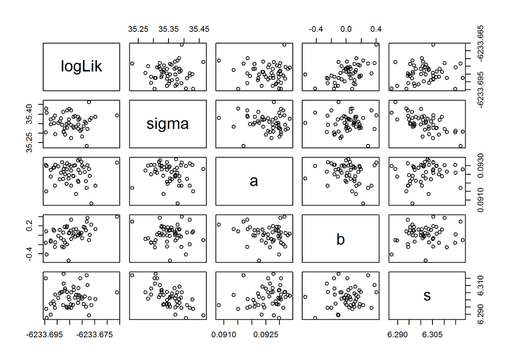

```r
pairs(~logLik+sigma+a+b+s,data=r.if1)
```

From the log-likelihood surface with respect to different parameters, we see that peaks are significant for all parameters. S and $\sigma$ have negative linear relationship. Because the s and $\sigma$ both serve to increase the volatility.

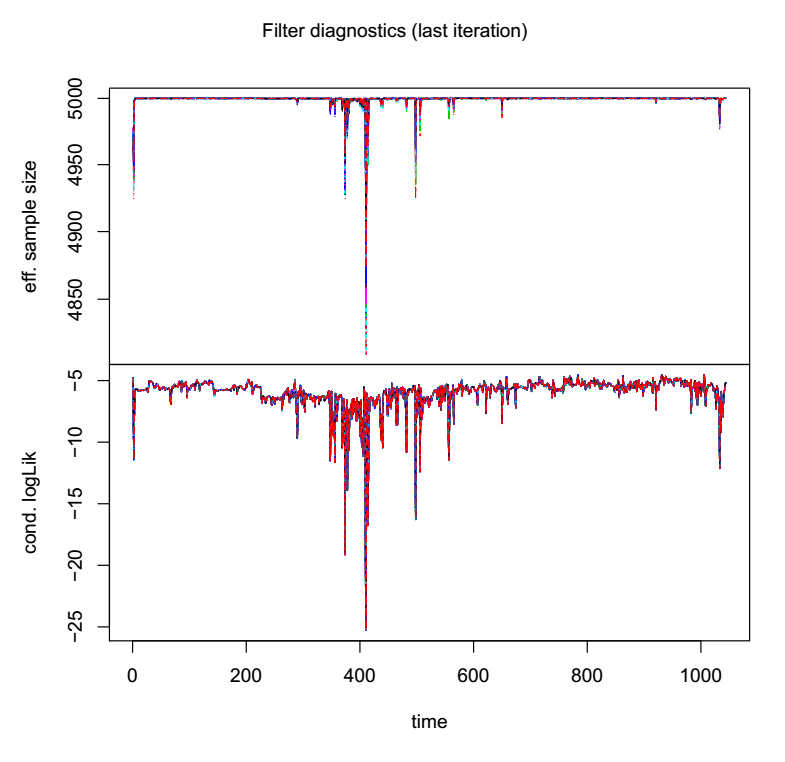

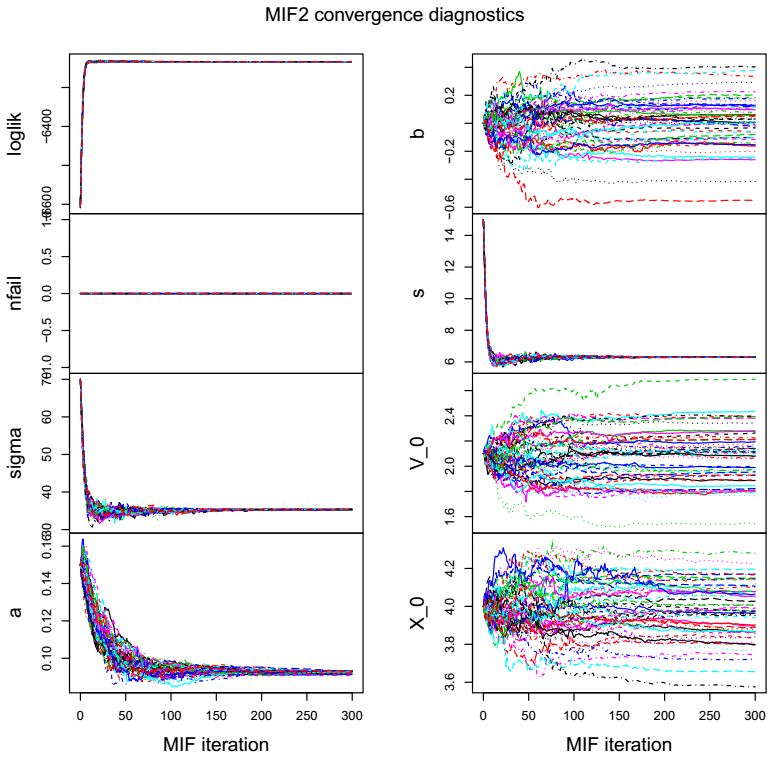

```r
#plot(if1)
```

According to the filter and convergence diagnostic, the efficient sample size is large enough. The likelihood achieves the maximum at 20 and lasts until end of iteration. $\sigma$, a and s have nice convergence and become flat within a very small interval.

From the filter diagnostics we can see that the effective sample size is always quite high except when time is around 400. The loglikelihood is also quite high. In general the effective sample size is above 4800 which is quite good.

# Likelihood maximization using randomized starting values

For better estimating parameters, we need to try different initial values of parameters. We could set a value box in parameter space and then randomly choose initial values from this box. As for the specification for the box, I found that this model seems to be very sensitive to initial values and it is very frequent that “dmeasure gives non-finite values”. After many practice, I finally come to the box shown below with a relatively small interval for each parameter.

```r
##--------Likelihood maximization using randomized starting values--------

CSIspreads_box <- rbind(
       sigma =c(10,100),
     a=c(0.001,0.999),
     b = c(-50,50),
     s=c(1,50),
     V_0= c(10,100),
     X_0= c(-50,50)
)

stew(file=sprintf("box_eval-%d.rda",run_level),{
  t.box <- system.time({
    if.box <- foreach(i=1:CSIspreads_Nreps_global[run_level],.packages='pomp',.combine=c,
                  .options.multicore=list(set.seed=TRUE),.export = c('CSIspreads_Np',
'CSIspreads_Nmif','CSIspreads_Nreps_eval','CSIspreads_Nreps_local','CSIspreads_Nreps_global','CSIspreads_rw.sd_rp','CSIspreads_rw.sd_ivp','CSIspreads_cooling.fraction.50','dow.filt','run_level','params_test','if1','CSIspreads_box')) %dopar%
      mif2(
        if1[[1]],
        start=apply(CSIspreads_box,1,function(x)runif(1,x[1],x[2]))
      )

    L.box <- foreach(i=1:CSIspreads_Nreps_global[run_level],.packages='pomp',.combine=rbind,
                      .options.multicore=list(set.seed=TRUE),.export = c('CSIspreads_Np',
'CSIspreads_Nmif','CSIspreads_Nreps_eval','CSIspreads_Nreps_local','CSIspreads_Nreps_global','CSIspreads_rw.sd_rp','CSIspreads_rw.sd_ivp','CSIspreads_cooling.fraction.50','dow.filt','run_level','params_test','if1','CSIspreads_box')) %dopar% {
                        set.seed(87932+i)
                        logmeanexp(
                          replicate(CSIspreads_Nreps_eval[run_level],
                                    logLik(pfilter(dow.filt,params=coef(if.box[[i]]),Np=CSIspreads_Np[run_level]))
                          ),
                          se=TRUE)
                      }
  })
},seed=453267856,kind="L'Ecuyer")

r.box <- data.frame(logLik=L.box[,1],logLik_se=L.box[,2],t(sapply(if.box,coef)))
if(run_level>1) write.table(r.box,file="CSIspreads_params.csv",append=TRUE,col.names=FALSE,row.names=FALSE)
summary(r.box$logLik,digits=5)
```

```
##    Min. 1st Qu.  Median    Mean 3rd Qu.    Max.
##   -6241   -6235   -6235   -6235   -6234   -6234
```

```r
r.box[which.max(r.box$logLik),]
```

```
##              logLik    logLik_se    sigma          a        b        s
## result.47 -6233.844 0.0005044258 35.39093 0.09253351 4.236419 6.293695
##               V_0      X_0
## result.47 17.8144 2.510589
```

The maximum logLikelihood is -6233.844, and parameters which maximizes the likelihood are also shown.

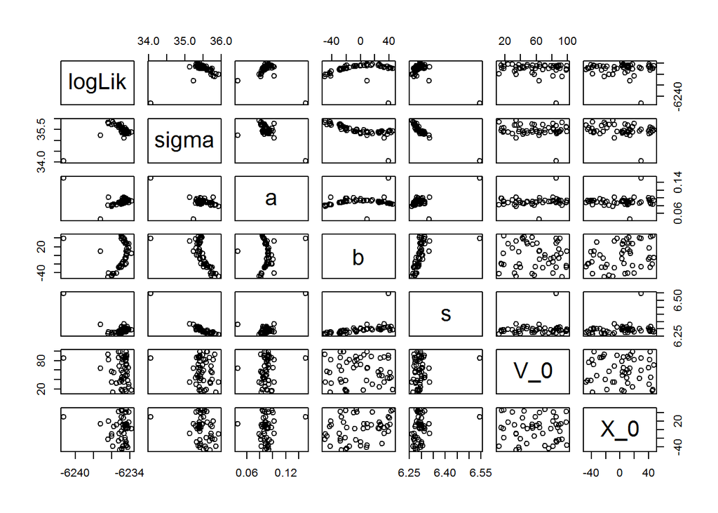

```r
pairs(~logLik+sigma+a+b+s+V_0+X_0,data=r.box)
```

```r
#plot(if.box)
```

From the log-likelihood surface with respect to different parameters, we see that peaks are significant for all parameters. S and $\sigma$ have negative linear relationship. Because the s and $\sigma$ both serve to increase the volatility.

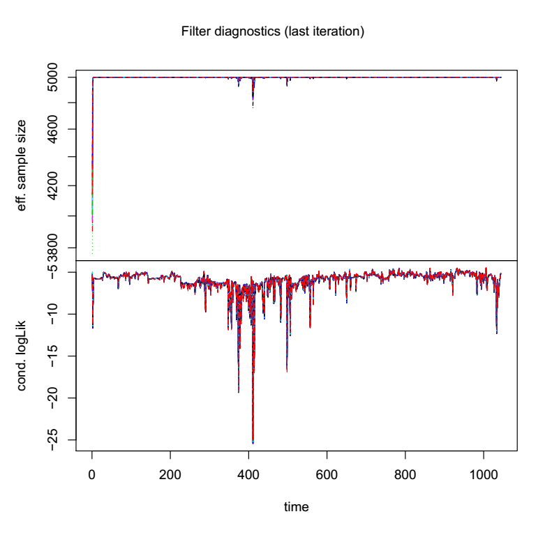

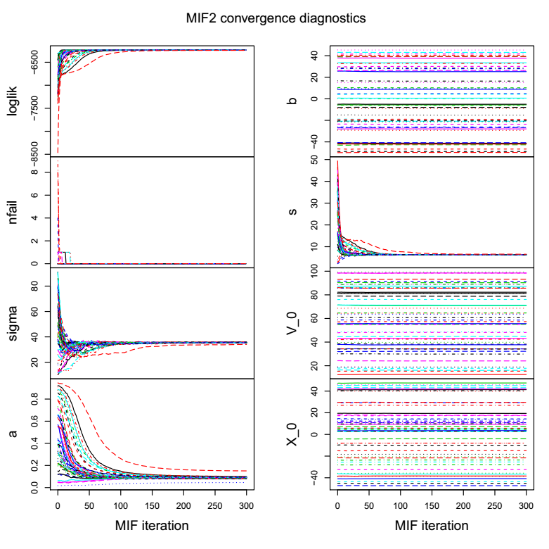

# Patterns of Calibrated Model Compared with Historical Data

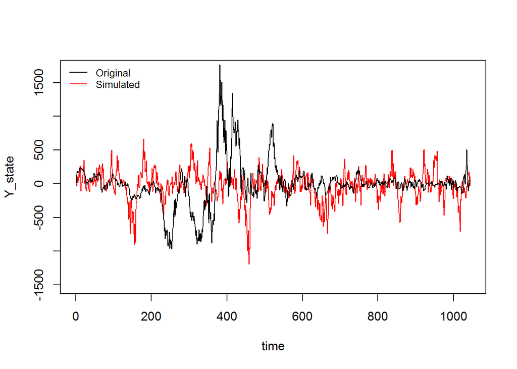

```r
params_test <- c(
     sigma =35.39093,
     a=0.09253351,
     b = 4.236419,
     s=6.293695,
     V_0= 17.8144,
     X_0=2.510589
  )
set.seed(700)
sim1.sim <- pomp(dow.filt,
               statenames=CSIspreads_statenames,
               paramnames=CSIspreads_paramnames,
               covarnames=CSIspreads_covarnames,
               rprocess=discrete.time.sim(step.fun=Csnippet(CSIspreads_rproc.sim),delta.t=1)
)

sim1.sim <- simulate(sim1.sim,seed=1,params=params_test)
plot(Y_state~time,data=sim1.sim,type='l',col="red",ylim=c(-1500,1700))
lines(CSIspreads_value,type='l')
legend("topleft",legend=c("Original","Simulated"),col=c("black","red"),
       cex=0.8,lty=1,bty="n")
```

# Benchmark Log-likelihoods for GARCH Models

Finally, we compare our model with GARCH model to evaluate the success of our model.

```r
library(tseries)
L.garch.benchmark = logLik(garch(CSIspreads_value))
```

[output not shown]

```r
L.garch.benchmark
```

```
## 'log Lik.' -7233.367 (df=3)
```

# Conclusion and Discussion on the Improvement

First, according to simulations, the mean reversion and self-exciting volatility are well depicted in this spread model. It also has nice mathematical characteristics. It will not explode.

Given initial values and starting values, the sigma, s and a converges well. Sigma should be around 35.3932. S should be around 6.305309 while a is 0.09316657. Parameter b does not converge well which is acceptable because the stationary mean model does not seem to fit the data although we know that in the long run the spread process should have mean 0.

If the starting values are randomized, sigma convergences to 35.39093. Parameter a converges to 0.09253351. Parameter s converges to 6.293695. Parameter b does not converge. Obviously the data has non-constant mean and non-constant variance. In genreral, we can determine sigma, a and s in this model.

From the filter diagnostics perspective, we believe this is a good model. The effective sample size and log-likelihood are quite high and do not decay as time goes by.

In this model, I make the simulations heavier tails by changing the coefficient of the drift term. For future improvement, I might use t-distribution to serve as drift. Another method might be changing the power of the absolute value of $Y_state$.

Because the time horizon is so long, the patterns of this spread time series may have already changed. In practice, this model might be more useful in local forecasting and predicting. Moreover, the coefficient of the difussion term can also make it $|b-Y_{t-1}|$ to capture how much it deviates from the mean rather than the magnitude of $|Y_t|$.

To find an appropriate model and forecast the spreads, we can use more than the spread time series itself. More relative information can boost the accuracy of the prediction and modelling. Time series models with covariates are my improvement directions. For example, interest rate also plays a vital part in determing spread. More generally, the commodity futures spreads are even influenced by the production cost and storage cost$^{[16]}$.

After obtaining the model and parameters of this model, we gained better understanding of the dynamics of the spreads. We can even calculate the exit time, optimal stopping time, the distribution of running maximum and minimum to enhance our performance in trading decisions.

# Reference

[1] Shreve, S. E. (2004). Stochastic calculus for finance II: Continuous-time models (Vol. 11). Springer Science & Business Media.

[2] Ionides, E. L., Nguyen, D., Atchadé, Y., Stoev, S., & King, A. A. (2015). Inference for dynamic and latent variable models via iterated, perturbed Bayes maps. Proceedings of the National Academy of Sciences, 112(3), 719-724.

[3] Lien, D., & Yang, L. (2006). Spot‐futures spread, time‐varying correlation, and hedging with currency futures. Journal of Futures Markets, 26(10), 1019-1038.

[4] King, A. A., Nguyen, D., & Ionides, E. L. (2015). Statistical inference for partially observed Markov processes via the R package pomp. arXiv preprint arXiv:1509.00503.

[5] Pindyck, R. S. (2001). The dynamics of commodity spot and futures markets: a primer. The Energy Journal, 1-29.

[6] https://ionides.github.io/531w18/midterm_project/project20/MidtermProject.html

[7] Xiao, W., Zhang, W., & Xu, W. (2011). Parameter estimation for fractional Ornstein–Uhlenbeck processes at discrete observation. Applied Mathematical Modelling, 35(9), 4196-4207.

[8] El Onsy, B., Es-Sebaiy, K., & G. Viens, F. (2017). Parameter estimation for a partially observed Ornstein–Uhlenbeck process with long-memory noise. Stochastics, 89(2), 431-468.

[9] Xiao, W., Zhang, W., & Xu, W. (2011). Parameter estimation for fractional Ornstein–Uhlenbeck processes at discrete observation. Applied Mathematical Modelling, 35(9), 4196-4207.

[10] https://ionides.github.io/531w18/14/notes14.html

[11] Hofmann, K. F., & Schulz, T. (2016). A General Ornstein–Uhlenbeck Stochastic Volatility Model With Lévy Jumps. International Journal of Theoretical and Applied Finance, 19(08), 1650044.

[12] Kavitha, G., Udhayakumar, A., & Nagarajan, D. (2013). Stock market trend analysis using hidden markov models. arXiv preprint arXiv:1311.4771.

[13] Pirrong, S. C., Haddock, D., & Kormendi, R. C. (2012). Grain Futures Contracts: An Economic Appraisal. Springer Science & Business Media.

[14] Kim, M. K., & Leuthold, R. M. (2000). The Distributional Behavior of Futures Price Spreads. Journal of Agricultural and Applied Economics, 32(1), 73-87.

[15] Hazen, T. L. (1987). Volatility and Market Inefficiency: A Commentary on the Effects of Options, Futures, and Risk Arbitrage on the Stock Market. Wash. & Lee L. Rev., 44, 789.

[16] Carmona, R., & Ludkovski, M. (2004). Spot convenience yield models for the energy markets. Contemporary Mathematics, 351, 65-80.